# HW_2

Glebus Alexandr

2024-02-04

## Загрузка данных

Загрузим данные, выберем нужные, сделаем EDA

```r
cataract <- read.csv('congenital_cataract.csv', ) %>%
  select(-X) %>%
  mutate(id = as.numeric(id),
       age_flwp = as.numeric(age_flwp),
       strat = as.factor(strat),
       side = as.factor(side),
       glau = as.factor(glau),
       bcdva = as.numeric(bcdva),
       bcnva = as.numeric(bcnva))
cataract %>% summary()
```

```
##        id           age_flwp             strat    side    glau
##  Min.   :133.0   Min.   : 6.200   Aphakia   :25   L:27   No :37
##  1st Qu.:282.0   1st Qu.: 9.325   Artephakia:37   R:35   Yes:25
##  Median :524.0   Median :11.450
##  Mean   :494.4   Mean   :11.634
##  3rd Qu.:667.8   3rd Qu.:14.550
##  Max.   :897.0   Max.   :17.000
##      bcdva             bcnva
##  Min.   :0.00456   Min.   :0.01750
##  1st Qu.:0.03406   1st Qu.:0.09563
##  Median :0.10426   Median :0.25601
##  Mean   :0.16296   Mean   :0.32469
##  3rd Qu.:0.21347   3rd Qu.:0.50330
##  Max.   :0.80000   Max.   :0.95354
```

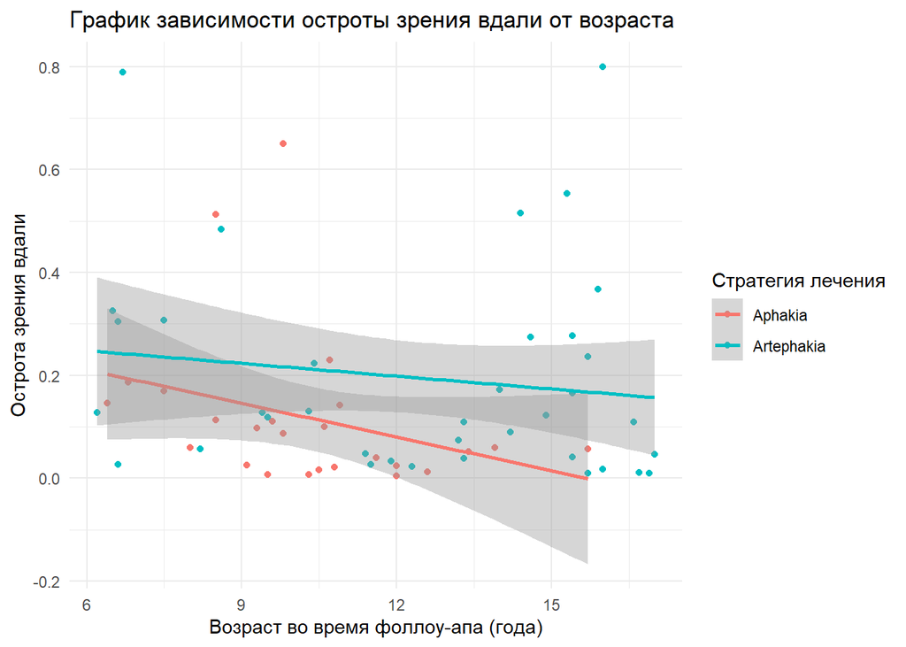

```r
# График для остроты зрения вдали (bcdva)
ggplot(cataract, aes(x = age_flwp, y = bcdva, color = strat)) +
  geom_point() +
  geom_smooth(method = lm) +
  labs(title = "График зависимости остроты зрения вдали от возраста",
       x = "Возраст во время фоллоу-апа (года)",
       y = "Острота зрения вдали",
       color = "Стратегия лечения") +
  theme_minimal()
```

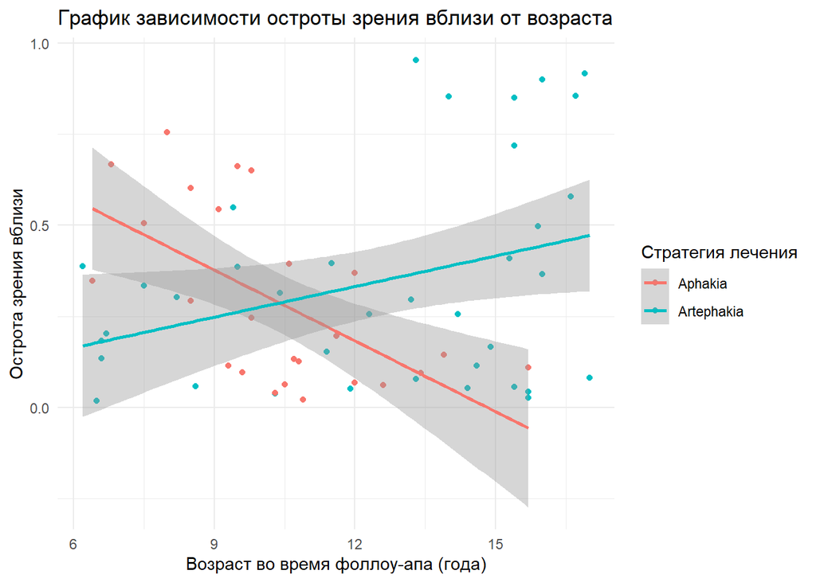

```r
# График для остроты зрения вблизи (bcnva)
ggplot(cataract, aes(x = age_flwp, y = bcnva, color = strat)) +
  geom_point() +
  geom_smooth(method = lm) +
  labs(title = "График зависимости остроты зрения вблизи от возраста",
       x = "Возраст во время фоллоу-апа (года)",
       y = "Острота зрения вблизи",
       color = "Стратегия лечения") +
  theme_minimal()
```

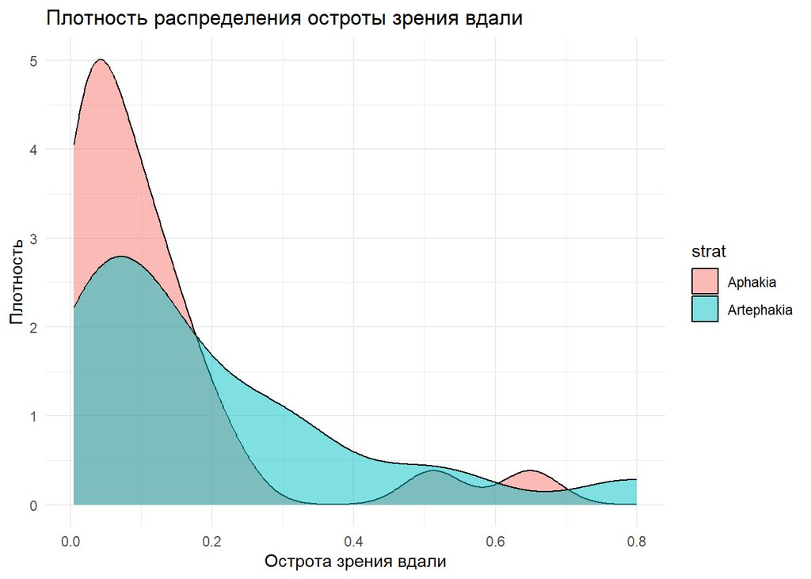

```r
# График для остроты зрения вдали (bcdva)
ggplot(cataract) +
  geom_density(aes(x = bcdva, fill = strat), alpha = 0.5) +
  labs(title = "Плотность распределения остроты зрения вдали",
       x = "Острота зрения вдали",
       y = "Плотность") +
  theme_minimal()
```

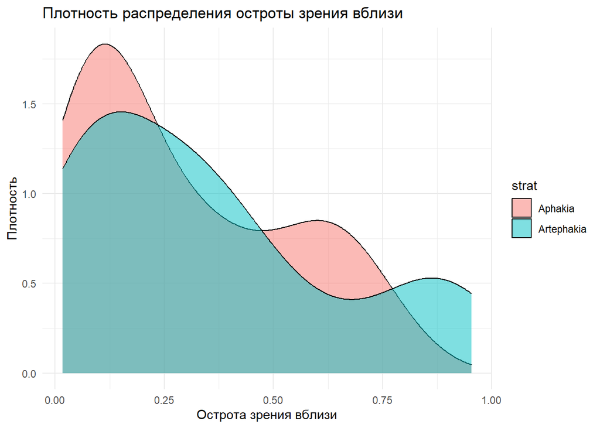

```r
# График для остроты зрения вблизи (bcnva)
ggplot(cataract) +
  geom_density(aes(x = bcnva, fill = strat), alpha = 0.5) +
  labs(title = "Плотность распределения остроты зрения вблизи",
       x = "Острота зрения вблизи",
       y = "Плотность") +
  theme_minimal()
```

Разделим остротe зрения вдали на две области (острота зрения < 0.4 и острота зрения > 0.4). В группе низкого зрения худшим зрением обладают пациенты с афакией на основе визуальной оценки. А в группе высокого зрения на основе визуальной оценки не видно преобладания какой либо стратегии. Рассмотрим график отстроты зрения вблизи. Не видно преобладания какой либо стратегии. Распределение остроты зрения и для Афакии и для Артефакии ненормальное. Возможно, стоит это учесть при построении моделей.

## 1. Какая стратегия предпочтительна для лечения врожденной катаракты, с точки зрения остроты зрения? Не используйте информацию о наличии глаукомы при ответе на этот вопрос.

### 1.1. Оцените эффект стратегии без коррекции на ковариаты.

```r
fit1 <- lm(bcdva ~ strat, data = cataract)
fit2 <- lm(bcnva ~ strat, data = cataract)
# Визуализируем
modelsummary(
  list(fit1, fit2), statistic = "{p.value} [{conf.low}, {conf.high}]")
```

|  | (1) | (2) |
| --- | --- | --- |
| (Intercept) | 0.117 | 0.292 |
|  | 0.003 [0.042, 0.192] | <0.001 [0.182, 0.402] |
| stratArtephakia | 0.077 | 0.055 |
|  | 0.118 [-0.020, 0.174] | 0.446 [-0.088, 0.197] |
| Num.Obs. | 62 | 62 |
| R2 | 0.040 | 0.010 |
| R2 Adj. | 0.024 | -0.007 |
| AIC | -27.5 | 19.6 |
| BIC | -21.1 | 26.0 |
| Log.Lik. | 16.742 | -6.810 |
| F | 2.516 | 0.589 |
| RMSE | 0.18 | 0.27 |

Модели без учета возраста, наличия глаукомы, стороны, на которой была проведена операция не показывают значимых связей стратегий лечения с остротой зрения.

### 1.2. Оцените эффект стратегии с коррекцией на ковариаты. Обоснуйте необходимость включения каждой ковариаты в вашу модель.

Включим в модель переменные отвечающие за стратегию, возраст и сторону, на который была проведена операция, потому что они могут повлиять на эффективность терапии. Фактор глаукомы не включен по условию. Острота зрения вблизи и вдали ассоциированы, поэтому не будем одновременно включать их в модель.

```r
fit1 <- lm(bcnva ~ strat + age_flwp + side, data = cataract)
fit2 <- lm(bcdva ~ strat + age_flwp + side, data = cataract)
modelsummary(
  list(fit1, fit2), statistic = "{p.value} [{conf.low}, {conf.high}]")
```

|  | (1) | (2) |
| --- | --- | --- |
| (Intercept) | 0.177 | 0.246 |
|  | 0.213 [-0.104, 0.459] | 0.012 [0.056, 0.437] |
| stratArtephakia | 0.034 | 0.102 |
|  | 0.662 [-0.119, 0.186] | 0.052 [-0.001, 0.206] |
| age_flwp | 0.009 | -0.011 |
|  | 0.424 [-0.014, 0.033] | 0.156 [-0.027, 0.004] |
| sideR | 0.032 | -0.022 |
|  | 0.651 [-0.110, 0.175] | 0.645 [-0.119, 0.074] |
| Num.Obs. | 62 | 62 |
| R2 | 0.023 | 0.075 |
| R2 Adj. | -0.027 | 0.027 |
| AIC | 22.8 | -25.8 |
| BIC | 33.4 | -15.2 |
| Log.Lik. | -6.382 | 17.894 |
| F | 0.461 | 1.573 |
| RMSE | 0.27 | 0.18 |

Оценим распределение остатков

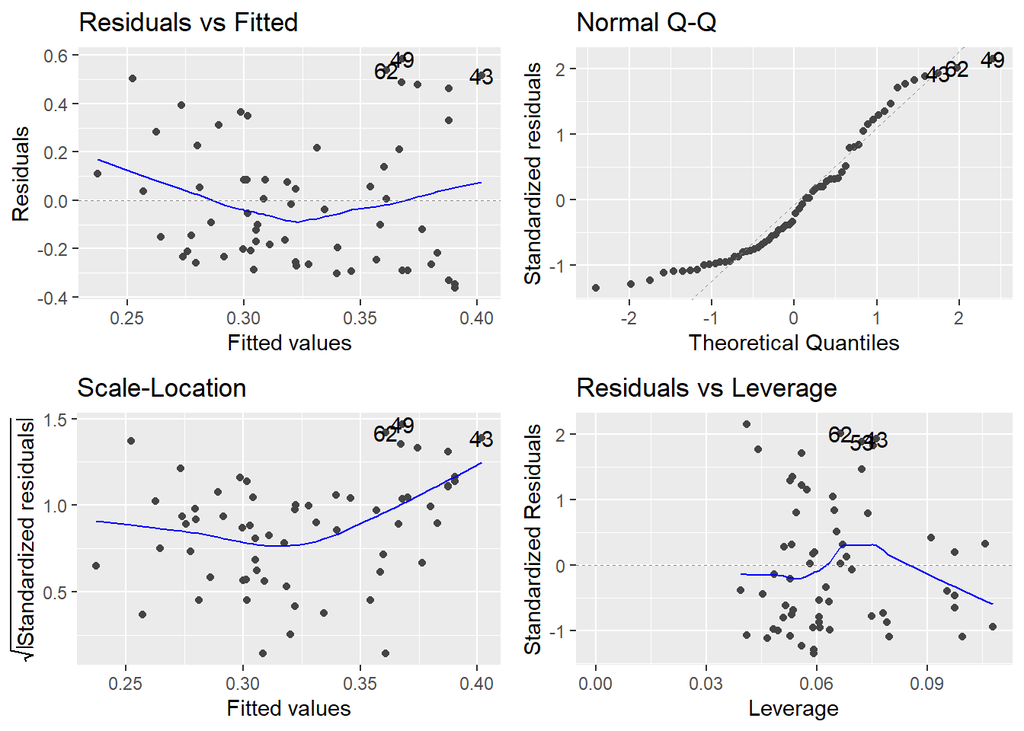

```r
autoplot(fit1)
```

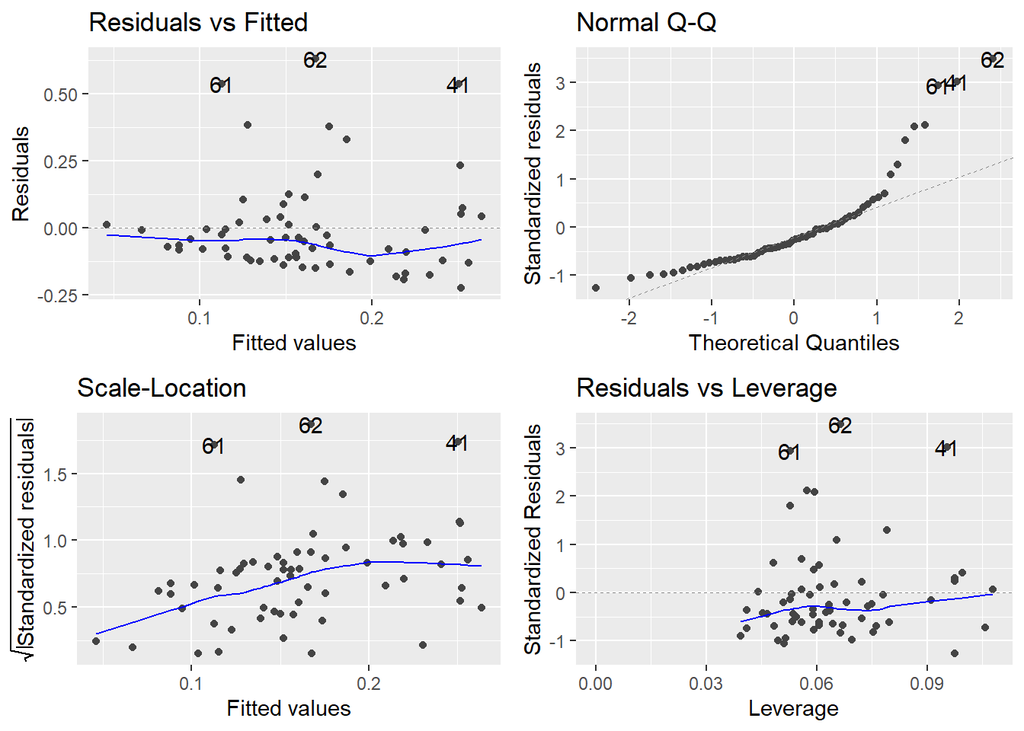

```r
autoplot(fit2)
```

Наблюдается небольшое отклонение он нормальности остатков регрессии, гетероскедастичность. Кластеризации остатков не наблюдается.

Проведем коррекцию на гетероскедастичность.

```r
robust_fit1 <- coeftest(fit1, vcov = vcovHC, type = "HC4")
robust_fit2 <- coeftest(fit2, vcov = vcovHC, type = "HC4")
modelsummary(
  list(robust_fit1, robust_fit2), statistic = "{p.value} [{conf.low}, {conf.high}]")
```

|  | (1) | (2) |
| --- | --- | --- |
| (Intercept) | 0.177 | 0.246 |
|  | 0.221 [-0.110, 0.464] | 0.006 [0.075, 0.418] |
| stratArtephakia | 0.034 | 0.102 |
|  | 0.598 [-0.093, 0.160] | 0.043 [0.003, 0.202] |
| age_flwp | 0.009 | -0.011 |
|  | 0.416 [-0.014, 0.032] | 0.202 [-0.029, 0.006] |
| sideR | 0.032 | -0.022 |
|  | 0.645 [-0.107, 0.172] | 0.636 [-0.116, 0.072] |
| Num.Obs. | 62 | 62 |
| AIC | 128.8 | 80.2 |
| BIC | 252.1 | 203.6 |

Если выбрана стратегия Артефакия, то среднее значение острота зрения вдали увеличится на примерно 0.1016 по сравнению с Афакия (p = 0.043) при прочих равных обстоятельствах. Для остроты зрения вблизи статистической разницы не обнаружено.

## 2. Какой эффект оказывает глаукома на остроту зрения? Зависит ли этот эффект от выбранной стратегии? Опишите эффект от терапии с учетом потенциального развития глаукомы. Какая терапия предпочтительнее с учетом потенциального развития глаукомы?

### 2.1. Оцените эффект без коррекции на ковариаты.

Модель без ковариат.

```r
fit1 <- lm(bcdva ~ glau, data = cataract)
fit2 <- lm(bcnva ~ glau, data = cataract)
# Визуализируем
modelsummary(
  list(fit1, fit2), statistic = "{p.value} [{conf.low}, {conf.high}]")
```

|  | (1) | (2) |
| --- | --- | --- |
| (Intercept) | 0.178 | 0.345 |
|  | <0.001 [0.115, 0.240] | <0.001 [0.254, 0.435] |
| glauYes | -0.036 | -0.050 |
|  | 0.465 [-0.135, 0.063] | 0.485 [-0.192, 0.092] |
| Num.Obs. | 62 | 62 |
| R2 | 0.009 | 0.008 |
| R2 Adj. | -0.008 | -0.008 |
| AIC | -25.5 | 19.7 |
| BIC | -19.1 | 26.1 |
| Log.Lik. | 15.747 | -6.859 |
| F | 0.540 | 0.493 |
| RMSE | 0.19 | 0.27 |

Влияние глаукомы на остроту зрения может быть слабо отрицательным, однако результ не является статистически значимым.

Добавим пересечение фактора глаукоы и фактора стратегии, потому что наличие глаукомы может по разному влиять на остроту зрения, в зависимости от выбранной стратегии.

```r
fit1 <- lm(bcdva ~ glau * strat, data = cataract)
fit2 <- lm(bcnva ~ glau * strat, data = cataract)
modelsummary(
  list(fit1, fit2), statistic = "{p.value} [{conf.low}, {conf.high}]")
```

|  | (1) | (2) |
| --- | --- | --- |
| (Intercept) | 0.098 | 0.241 |
|  | 0.065 [-0.006, 0.203] | 0.002 [0.091, 0.391] |
| glauYes | 0.039 | 0.107 |
|  | 0.611 [-0.112, 0.190] | 0.329 [-0.110, 0.324] |
| stratArtephakia | 0.122 | 0.160 |
|  | 0.065 [-0.008, 0.252] | 0.091 [-0.026, 0.347] |
| glauYes × stratArtephakia | -0.114 | -0.262 |
|  | 0.258 [-0.313, 0.085] | 0.072 [-0.548, 0.024] |
| Num.Obs. | 62 | 62 |
| R2 | 0.066 | 0.070 |
| R2 Adj. | 0.018 | 0.021 |
| AIC | -25.2 | 19.8 |
| BIC | -14.5 | 30.4 |
| Log.Lik. | 17.588 | -4.875 |
| F | 1.368 | 1.447 |
| RMSE | 0.18 | 0.26 |

Мы не можем судить о превосходстве одной терапии над другой.

### 2.2. Оцените эффект с коррекцией на ковариаты. Обоснуйте необходимость включения каждой ковариаты в вашу модель.

Добавим ковариаты: возраст и сторона, на которой была проведена операция, так как они могут влиять на результат терапии.

```r
fit1 <- lm(bcdva ~ strat * glau + age_flwp + side, data = cataract)
fit2 <- lm(bcnva ~ strat * glau + age_flwp + side, data = cataract)
modelsummary(
  list(fit1, fit2), statistic = "{p.value} [{conf.low}, {conf.high}]")
```

|  | (1) | (2) |
| --- | --- | --- |
| (Intercept) | 0.243 | 0.153 |
|  | 0.021 [0.039, 0.448] | 0.312 [-0.147, 0.452] |
| stratArtephakia | 0.155 | 0.140 |
|  | 0.026 [0.020, 0.290] | 0.162 [-0.058, 0.338] |
| glauYes | 0.039 | 0.107 |
|  | 0.604 [-0.111, 0.189] | 0.336 [-0.114, 0.327] |
| age_flwp | -0.012 | 0.008 |
|  | 0.123 [-0.028, 0.003] | 0.510 [-0.016, 0.031] |
| sideR | -0.032 | 0.016 |
|  | 0.518 [-0.129, 0.066] | 0.818 [-0.126, 0.159] |
| stratArtephakia × glauYes | -0.128 | -0.253 |
|  | 0.202 [-0.328, 0.071] | 0.088 [-0.545, 0.039] |
| Num.Obs. | 62 | 62 |
| R2 | 0.109 | 0.077 |
| R2 Adj. | 0.030 | -0.005 |
| AIC | -24.1 | 23.2 |
| BIC | -9.2 | 38.1 |
| Log.Lik. | 19.058 | -4.616 |
| F | 1.375 | 0.939 |
| RMSE | 0.18 | 0.26 |

Оценим распределение регрессионных остатков

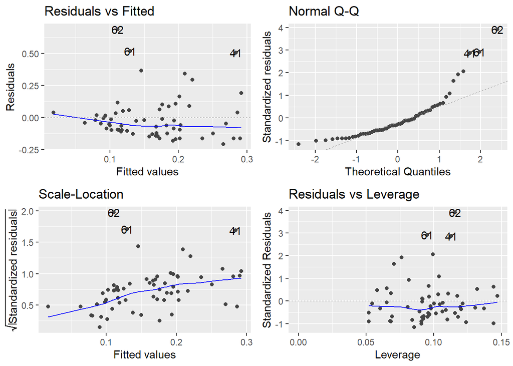

```r
autoplot(fit1)
```

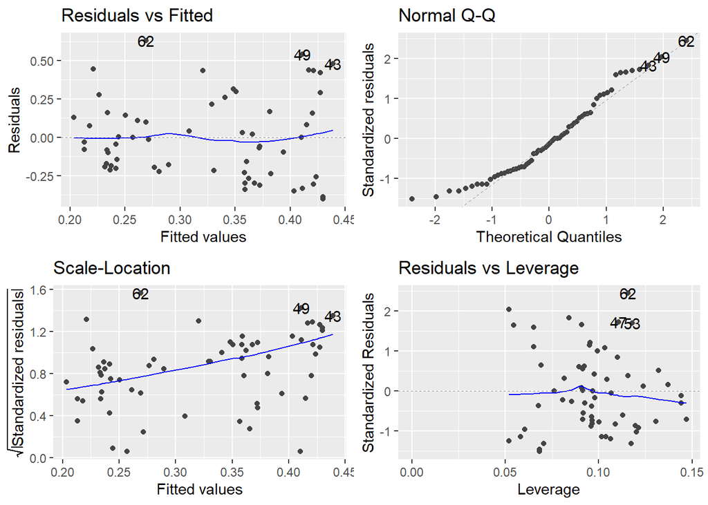

```r
autoplot(fit2)
```

Наблюдается небольшое отклонение он нормальности остатков регрессии, гетероскедастичность. Кластеризации остатков не наблюдается. Проведем коррекцию на гетероскедастичность.

```r
fit1 <- lm(bcdva ~ strat * glau + age_flwp + side, data = cataract)
robust_fit1 <- coeftest(fit1, vcov = vcovHC, type = "HC4")
fit2 <- lm(bcnva ~ strat * glau + age_flwp + side, data = cataract)
robust_fit2 <- coeftest(fit2, vcov = vcovHC, type = "HC4")
modelsummary(
  list(robust_fit1, robust_fit2), statistic = "{p.value} [{conf.low}, {conf.high}]")
```

|  | (1) | (2) |
| --- | --- | --- |
| (Intercept) | 0.243 | 0.153 |
|  | 0.008 [0.065, 0.422] | 0.298 [-0.138, 0.443] |
| stratArtephakia | 0.155 | 0.140 |
|  | 0.006 [0.047, 0.263] | 0.085 [-0.020, 0.300] |
| glauYes | 0.039 | 0.107 |
|  | 0.542 [-0.089, 0.167] | 0.304 [-0.099, 0.312] |
| age_flwp | -0.012 | 0.008 |
|  | 0.185 [-0.031, 0.006] | 0.506 [-0.015, 0.031] |
| sideR | -0.032 | 0.016 |
|  | 0.481 [-0.121, 0.058] | 0.806 [-0.117, 0.150] |
| stratArtephakia × glauYes | -0.128 | -0.253 |
|  | 0.195 [-0.325, 0.068] | 0.066 [-0.524, 0.017] |
| Num.Obs. | 62 | 62 |
| AIC | 73.9 | 121.2 |
| BIC | 193.0 | 240.4 |

Взаимодействие между стратегией “Артефакия” и наличием глаукомы указывает на то, что эффект “Артефакии” может изменяться в зависимости от наличия глаукомы. Результаты не достигли статистической значимости. Врачам следует с осторожностью выбирать стратегию “Артефакия” к пациентам с потенциальным развитием глаукомы, потому что влияние глаукомы при стратегии “Артефакия” на остроту зрения может быть отрицательным.

## 3. Как связана частота развития глаукомы с выбранной стратегией?

### 3.1. Оцените эффект стратегии без коррекции на ковариаты.

Построим логистическую регрессию без ковариат.

```r
fit <- glm(glau ~  strat, data = cataract, family = binomial)
modelsummary(
  list(fit), statistic = "{p.value} [{conf.low}, {conf.high}]")
```

|  | (1) |
| --- | --- |
| (Intercept) | -0.080 |
|  | 0.842 [-0.879, 0.711] |
| stratArtephakia | -0.533 |
|  | 0.313 [-1.582, 0.501] |
| Num.Obs. | 62 |
| AIC | 86.6 |
| BIC | 90.8 |
| Log.Lik. | -41.295 |
| F | 1.019 |
| RMSE | 0.49 |

В целом, эти результаты позволяют сделать предварительные выводы о связи выбранной стратегии с развитием глаукомы. Однако, статистическая значимость пока не подтверждает наличие этой связи.

### 3.2. Оцените эффект стратегии с коррекцией на ковариаты. Обоснуйте необходимость включения каждой ковариаты в вашу модель.

Добавим ковариаты. Остроту зрения добавлять не будем, чтобы избежать коллайдера.

```r
fit <- glm(glau ~ strat + age_flwp + side, data = cataract, family = binomial)
modelsummary(
  list(fit), statistic = "{p.value} [{conf.low}, {conf.high}]")
```

|  | (1) |
| --- | --- |
| (Intercept) | 0.657 |
|  | 0.531 [-1.403, 2.753] |
| stratArtephakia | -0.418 |
|  | 0.456 [-1.532, 0.685] |
| age_flwp | -0.054 |
|  | 0.538 [-0.227, 0.119] |
| sideR | -0.328 |
|  | 0.535 [-1.379, 0.712] |
| Num.Obs. | 62 |
| AIC | 89.9 |
| BIC | 98.4 |
| Log.Lik. | -40.939 |
| F | 0.563 |
| RMSE | 0.48 |

В целом, результаты показывают, что после коррекции на ковариаты эффект стратегии Артефакия остается отрицательным, но не является статистически значимым. При этом включение других ковариат также не приводит к статистически значимым результатам.